# Machine Learning Lab

## Lab 5 - Regression

Shyam Sundaram  
19BCE1560  
August 30, 2021  
Abdul Quadir Md  
L31+L32

```python
import matplotlib.pyplot as plt
import numpy as np
import pandas as pd
%matplotlib inline
```

# Creating data

```python
# Create our own data

datafile = pd.DataFrame()
datafile[0] = np.arange(2000,2020)
datafile[1] = [64,54,62,78,66,69,72,77,82,88,85,87,84,85,88,75,90,93,95,98]
datafile1 = pd.DataFrame()
datafile1[0] = np.arange(2000,2020)
datafile1[1] = np.random.randint(65,90,size=20)#[22,34,50,78,66,69,72,77,64,54,62,78,88,79,89,85,86,90,92,89]
datafile.columns =["Year","Placement"]
datafile1.columns =["Year","Placement"]
print(datafile)
print(datafile1)
```

```
    Year  Placement
0   2000         64
1   2001         54
2   2002         62
3   2003         78
4   2004         66
5   2005         69
6   2006         72
7   2007         77
8   2008         82
9   2009         88
10  2010         85
11  2011         87
12  2012         84
13  2013         85
```

[output cut: 27 more lines]

```
No handles with labels found to put in legend.
```

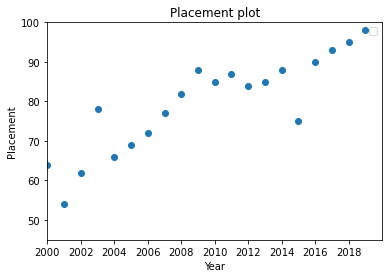

```python
plt.scatter(datafile['Year'],datafile['Placement'])
plt.title("Placement plot")
plt.xlim(2000,2020)
plt.ylim(45,100)
plt.xticks(np.arange(2000,2020,2))
plt.legend()
plt.xlabel("Year")
plt.ylabel("Placement")
plt.show()
```

# Correlation

```python
import seaborn as sb
```

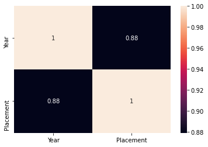

```python
data_corr = datafile.corr()
sb.heatmap(data_corr,annot=True)
```

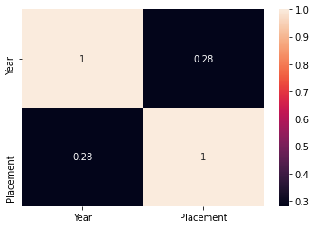

```python
data_corr = datafile1.corr()
sb.heatmap(data_corr,annot=True)
```

# Training Regression model

```python
from sklearn import linear_model
```

```python
regress = linear_model.LinearRegression()
```

## Separating attributes and target

```python
train_x = np.asanyarray(datafile[['Year']])
train_y = np.asanyarray(datafile[['Placement']])
print(train_x)
print(train_y)
```

```
[[2000]
 [2001]
 [2002]
 [2003]
 [2004]
 [2005]
 [2006]
 [2007]
 [2008]
 [2009]
 [2010]
 [2011]
 [2012]
 [2013]
 [2014]
 [2015]
 [2016]
 [2017]
 [2018]
 [2019]]
[[64]
 [54]
 [62]
 [78]
 [66]
 [69]
 [72]
 [77]
 [82]
 [88]
 [85]
 [87]
 [84]
 [85]
 [88]
 [75]
 [90]
 [93]
 [95]
 [98]]
```

## Training the model

```python
regress.fit (train_x,train_y)
```

```
LinearRegression()
```

## The coefficients: slope and intercept

```python
print ('Coefficients: ', regress.coef_)
print ('Intercept: ',regress.intercept_)
```

```
Coefficients:  [[1.78345865]]
Intercept:  [-3504.26015038]
```

## Plotting the regression line

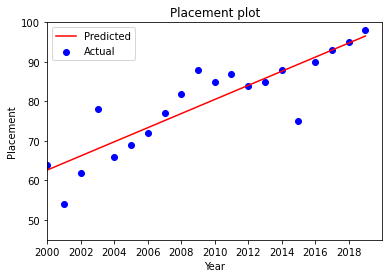

```python
plt.scatter(datafile.Year, datafile.Placement,  color='blue',label="Actual")
plt.plot(train_x, regress.coef_[0][0]*train_x + regress.intercept_[0], '-r',label="Predicted")
plt.title("Placement plot")
plt.xlim(2000,2020)
plt.ylim(45,100)
plt.xticks(np.arange(2000,2020,2))
plt.legend()
plt.xlabel("Year")
plt.ylabel("Placement")
plt.show()
```

## Regression model for second dataset

```python
regress1 = linear_model.LinearRegression()
train_x1 = np.asanyarray(datafile1[['Year']])
train_y1 = np.asanyarray(datafile1[['Placement']])
# print(train_x)
# print(train_y)

regress1.fit (train_x1,train_y1)
# The coefficients
print ('Coefficients: ', regress1.coef_)
print ('Intercept: ',regress1.intercept_)
```

```
Coefficients:  [[0.27744361]]
Intercept:  [-478.77293233]
```

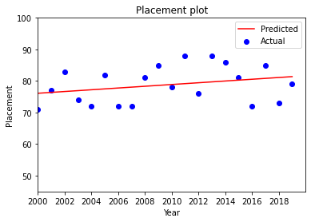

```python
plt.scatter(datafile1.Year, datafile1.Placement,  color='blue',label="Actual")
plt.plot(train_x, regress1.coef_[0][0]*train_x1 + regress1.intercept_[0], '-r',label="Predicted")
plt.title("Placement plot")
plt.xlim(2000,2020)
plt.ylim(45,100)
plt.xticks(np.arange(2000,2020,2))
plt.legend()
plt.xlabel("Year")
plt.ylabel("Placement")
plt.show()
```

# Predicting Values

```python
y_predicted = regress.predict(train_x)
for i in range(0,len(train_x)):
    print(train_y[i],y_predicted[i])
datafile['Predicted'] = y_predicted
print(y_predicted)
print(datafile.head())
```

```
[64] [62.65714286]
[54] [64.4406015]
[62] [66.22406015]
[78] [68.0075188]
[66] [69.79097744]
[69] [71.57443609]
[72] [73.35789474]
[77] [75.14135338]
[82] [76.92481203]
[88] [78.70827068]
[85] [80.49172932]
[87] [82.27518797]
[84] [84.05864662]
[85] [85.84210526]
[88] [87.62556391]
[75] [89.40902256]
[90] [91.1924812]
[93] [92.97593985]
[95] [94.7593985]
[98] [96.54285714]
[[62.65714286]
 [64.4406015 ]
 [66.22406015]
 [68.0075188 ]
 [69.79097744]
 [71.57443609]
 [73.35789474]
 [75.14135338]
 [76.92481203]
 [78.70827068]
 [80.49172932]
 [82.27518797]
 [84.05864662]
 [85.84210526]
 [87.62556391]
 [89.40902256]
 [91.1924812 ]
 [92.97593985]
 [94.7593985 ]
 [96.54285714]]
   Year  Placement  Predicted
0  2000         64  62.657143
1  2001         54  64.440602
2  2002         62  66.224060
3  2003         78  68.007519
4  2004         66  69.790977
```

## Measuring performance

Any of the following metrics may be used:

Mean absolute error: It is the average of the absolute value of all the errors.

Mean Squared Error (MSE): Mean Squared Error (MSE) is the mean of the squared error. This is efficient since the focus is on large errors and doesnot consider sign of error.

Root Mean Squared Error (RMSE): This is a metric to calculate the accuracy of the model. It represents how close the data are to the fitted regression line. The higher the R-squared, the better the model fits your data. Best possible score is 1.0 and it can be negative (because the model can be arbitrarily worse).

accuracy - 10/20 is the accu==50%

loss ---total errors happened in the system.

reduce the loss automatically the model becomes more accurate

```python
from sklearn import metrics
```

```python
print('Mean Absolute Error:', metrics.mean_absolute_error(train_y, y_predicted))
print('Mean Squared Error:', metrics.mean_squared_error(train_y, y_predicted))
print('Root Mean Squared Error:', np.sqrt(metrics.mean_squared_error(train_y, y_predicted)))
```

```
Mean Absolute Error: 3.8890225563910006
Mean Squared Error: 31.08090225563971
Root Mean Squared Error: 5.575024865921201
```

```python
from sklearn.metrics import r2_score
```

```python
test_x = np.asanyarray(datafile[['Year']])
test_y = np.asanyarray(datafile[['Placement']])
test_y_predicted = regress.predict(test_x)
```

```python
print("Mean absolute error (MAE):" , np.mean(np.absolute(test_y_predicted - test_y)))
print("Mean square error (MSE): " , np.mean((test_y_predicted - test_y) ** 2))
print("R2-score: %.2f (RMSE):" , r2_score(test_y, test_y_predicted) )
```

[output not shown]

# Splitting data: Training and testing

```python
from sklearn.model_selection import train_test_split
```

```python
train_x, test_x, train_y, test_y = train_test_split(datafile[['Year']], datafile[['Placement']], test_size=0.30, random_state=42)
print(train_x)
print("Testing")
print(test_x)
```

```
    Year
11  2011
3   2003
18  2018
16  2016
13  2013
2   2002
9   2009
19  2019
4   2004
12  2012
7   2007
10  2010
14  2014
6   2006
Testing
    Year
0   2000
17  2017
15  2015
1   2001
8   2008
5   2005
```

## Training on training data

```python
regress = linear_model.LinearRegression()
regress.fit (train_x,train_y)
# The coefficients
print ('Coefficients: ', regress.coef_)
print ('Intercept: ',regress.intercept_)
```

```
Coefficients:  [[1.73830735]]
Intercept:  [-3411.99443207]
```

## Evaluating with testing data

```python
y_predicted = regress.predict(test_x)
print(test_x)
print(test_y)
print(y_predicted)
```

```
    Year
0   2000
17  2017
15  2015
1   2001
8   2008
5   2005
    Placement
0          64
17         93
15         75
1          54
8          82
5          69
[[64.62026726]
 [94.1714922 ]
 [90.69487751]
 [66.35857461]
 [78.52672606]
 [73.31180401]]
```

```python
print('Mean Absolute Error:', metrics.mean_absolute_error(test_y, y_predicted))
print('Mean Squared Error:', metrics.mean_squared_error(test_y, y_predicted))
print('Root Mean Squared Error:', np.sqrt(metrics.mean_squared_error(test_y, y_predicted)))
```

```
Mean Absolute Error: 6.271714922049114
Mean Squared Error: 71.91265957675672
Root Mean Squared Error: 8.480133228715026
```

# Forest Fires dataset

```python
data = pd.read_csv("Week 5 Linear and Multilinear Regression Machine Learning Lab\\forestfires.csv")
data
```

|  | X | Y | month | day | FFMC | DMC | DC | ISI | temp | RH | wind | rain | area |
| --- | --- | --- | --- | --- | --- | --- | --- | --- | --- | --- | --- | --- | --- |
| 0 | 7 | 5 | mar | fri | 86.2 | 26.2 | 94.3 | 5.1 | 8.2 | 51 | 6.7 | 0.0 | 0.00 |
| 1 | 7 | 4 | oct | tue | 90.6 | 35.4 | 669.1 | 6.7 | 18.0 | 33 | 0.9 | 0.0 | 0.00 |
| 2 | 7 | 4 | oct | sat | 90.6 | 43.7 | 686.9 | 6.7 | 14.6 | 33 | 1.3 | 0.0 | 0.00 |
| 3 | 8 | 6 | mar | fri | 91.7 | 33.3 | 77.5 | 9.0 | 8.3 | 97 | 4.0 | 0.2 | 0.00 |
| 4 | 8 | 6 | mar | sun | 89.3 | 51.3 | 102.2 | 9.6 | 11.4 | 99 | 1.8 | 0.0 | 0.00 |
| ... | ... | ... | ... | ... | ... | ... | ... | ... | ... | ... | ... | ... | ... |
| 512 | 4 | 3 | aug | sun | 81.6 | 56.7 | 665.6 | 1.9 | 27.8 | 32 | 2.7 | 0.0 | 6.44 |
| 513 | 2 | 4 | aug | sun | 81.6 | 56.7 | 665.6 | 1.9 | 21.9 | 71 | 5.8 | 0.0 | 54.29 |
| 514 | 7 | 4 | aug | sun | 81.6 | 56.7 | 665.6 | 1.9 | 21.2 | 70 | 6.7 | 0.0 | 11.16 |
| 515 | 1 | 4 | aug | sat | 94.4 | 146.0 | 614.7 | 11.3 | 25.6 | 42 | 4.0 | 0.0 | 0.00 |
| 516 | 6 | 3 | nov | tue | 79.5 | 3.0 | 106.7 | 1.1 | 11.8 | 31 | 4.5 | 0.0 | 0.00 |

517 rows × 13 columns

## Describing the dataset

```python
data.shape
```

```
(517, 13)
```

```python
data.dtypes
```

```
X          int64
Y          int64
month     object
day       object
FFMC     float64
DMC      float64
DC       float64
ISI      float64
temp     float64
RH         int64
wind     float64
rain     float64
area     float64
dtype: object
```

## Encoding categorical values into numerical

```python
from sklearn import preprocessing
enc=preprocessing.LabelEncoder()
enc.fit(data['month'])
data['month']=enc.transform(data['month'])
enc.fit(data['day'])
data['day']=enc.transform(data['day'])
data
```

|  | X | Y | month | day | FFMC | DMC | DC | ISI | temp | RH | wind | rain | area |
| --- | --- | --- | --- | --- | --- | --- | --- | --- | --- | --- | --- | --- | --- |
| 0 | 7 | 5 | 7 | 0 | 86.2 | 26.2 | 94.3 | 5.1 | 8.2 | 51 | 6.7 | 0.0 | 0.00 |
| 1 | 7 | 4 | 10 | 5 | 90.6 | 35.4 | 669.1 | 6.7 | 18.0 | 33 | 0.9 | 0.0 | 0.00 |
| 2 | 7 | 4 | 10 | 2 | 90.6 | 43.7 | 686.9 | 6.7 | 14.6 | 33 | 1.3 | 0.0 | 0.00 |
| 3 | 8 | 6 | 7 | 0 | 91.7 | 33.3 | 77.5 | 9.0 | 8.3 | 97 | 4.0 | 0.2 | 0.00 |
| 4 | 8 | 6 | 7 | 3 | 89.3 | 51.3 | 102.2 | 9.6 | 11.4 | 99 | 1.8 | 0.0 | 0.00 |
| ... | ... | ... | ... | ... | ... | ... | ... | ... | ... | ... | ... | ... | ... |
| 512 | 4 | 3 | 1 | 3 | 81.6 | 56.7 | 665.6 | 1.9 | 27.8 | 32 | 2.7 | 0.0 | 6.44 |
| 513 | 2 | 4 | 1 | 3 | 81.6 | 56.7 | 665.6 | 1.9 | 21.9 | 71 | 5.8 | 0.0 | 54.29 |
| 514 | 7 | 4 | 1 | 3 | 81.6 | 56.7 | 665.6 | 1.9 | 21.2 | 70 | 6.7 | 0.0 | 11.16 |
| 515 | 1 | 4 | 1 | 2 | 94.4 | 146.0 | 614.7 | 11.3 | 25.6 | 42 | 4.0 | 0.0 | 0.00 |
| 516 | 6 | 3 | 9 | 5 | 79.5 | 3.0 | 106.7 | 1.1 | 11.8 | 31 | 4.5 | 0.0 | 0.00 |

517 rows × 13 columns

```python
data.describe()
```

|  | X | Y | month | day | FFMC | DMC | DC | ISI | temp | RH | wind | rain | area |
| --- | --- | --- | --- | --- | --- | --- | --- | --- | --- | --- | --- | --- | --- |
| count | 517.000000 | 517.000000 | 517.000000 | 517.000000 | 517.000000 | 517.000000 | 517.000000 | 517.000000 | 517.000000 | 517.000000 | 517.000000 | 517.000000 | 517.000000 |
| mean | 4.669246 | 4.299807 | 5.758221 | 2.736944 | 90.644681 | 110.872340 | 547.940039 | 9.021663 | 18.889168 | 44.288201 | 4.017602 | 0.021663 | 12.847292 |
| std | 2.313778 | 1.229900 | 4.373275 | 1.925061 | 5.520111 | 64.046482 | 248.066192 | 4.559477 | 5.806625 | 16.317469 | 1.791653 | 0.295959 | 63.655818 |
| min | 1.000000 | 2.000000 | 0.000000 | 0.000000 | 18.700000 | 1.100000 | 7.900000 | 0.000000 | 2.200000 | 15.000000 | 0.400000 | 0.000000 | 0.000000 |
| 25% | 3.000000 | 4.000000 | 1.000000 | 1.000000 | 90.200000 | 68.600000 | 437.700000 | 6.500000 | 15.500000 | 33.000000 | 2.700000 | 0.000000 | 0.000000 |
| 50% | 4.000000 | 4.000000 | 6.000000 | 3.000000 | 91.600000 | 108.300000 | 664.200000 | 8.400000 | 19.300000 | 42.000000 | 4.000000 | 0.000000 | 0.520000 |
| 75% | 7.000000 | 5.000000 | 11.000000 | 4.000000 | 92.900000 | 142.400000 | 713.900000 | 10.800000 | 22.800000 | 53.000000 | 4.900000 | 0.000000 | 6.570000 |
| max | 9.000000 | 9.000000 | 11.000000 | 6.000000 | 96.200000 | 291.300000 | 860.600000 | 56.100000 | 33.300000 | 100.000000 | 9.400000 | 6.400000 | 1090.840000 |

## Visualization

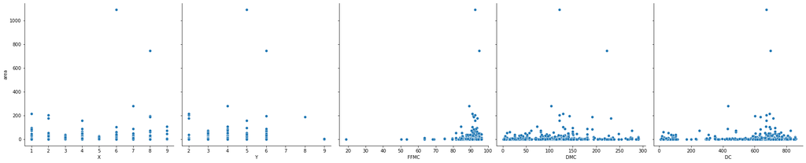

```python
sb.pairplot(data,x_vars=["X","Y","FFMC","DMC","DC"],y_vars=["area"],height=5)
```

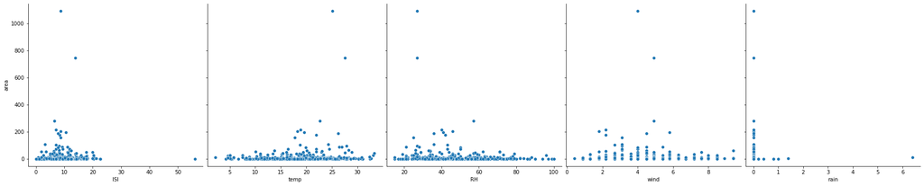

```python
sb.pairplot(data,x_vars=["ISI","temp","RH","wind","rain"],y_vars=["area"],height=5)
```

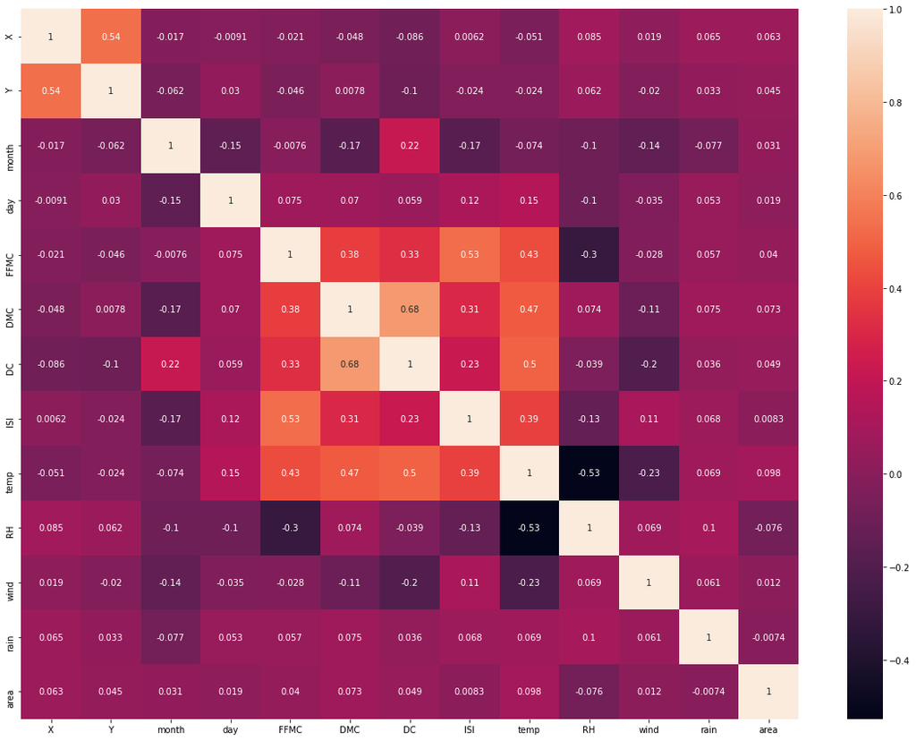

```python
plt.subplots(figsize=(20,15))
sb.heatmap(data.corr(),annot=True)
```

## Separating the features and target value

```python
data2=data.values
X=(data2[:,0:12])
y=data2[:,12]
X.shape
```

```
(517, 12)
```

```python
y.shape
```

```
(517,)
```

```python
X
```

```
array([[ 7. ,  5. ,  7. , ..., 51. ,  6.7,  0. ],
       [ 7. ,  4. , 10. , ..., 33. ,  0.9,  0. ],
       [ 7. ,  4. , 10. , ..., 33. ,  1.3,  0. ],
       ...,
       [ 7. ,  4. ,  1. , ..., 70. ,  6.7,  0. ],
       [ 1. ,  4. ,  1. , ..., 42. ,  4. ,  0. ],
       [ 6. ,  3. ,  9. , ..., 31. ,  4.5,  0. ]])
```

## Scaling the attributes

```python
minmax=preprocessing.MinMaxScaler()
```

```python
X=minmax.fit_transform(X)
X
```

```
array([[0.75      , 0.42857143, 0.63636364, ..., 0.42352941, 0.7       ,
        0.        ],
       [0.75      , 0.28571429, 0.90909091, ..., 0.21176471, 0.05555556,
        0.        ],
       [0.75      , 0.28571429, 0.90909091, ..., 0.21176471, 0.1       ,
        0.        ],
       ...,
       [0.75      , 0.28571429, 0.09090909, ..., 0.64705882, 0.7       ,
        0.        ],
       [0.        , 0.28571429, 0.09090909, ..., 0.31764706, 0.4       ,
        0.        ],
       [0.625     , 0.14285714, 0.81818182, ..., 0.18823529, 0.45555556,
        0.        ]])
```

## Splitting the training and testing data

```python
train_x, test_x, train_y, test_y = train_test_split(X,y, test_size=0.30, random_state=42)
```

## Forming the regression Model

```python
from sklearn import linear_model
reg=linear_model.LinearRegression()
```

```python
reg.fit(train_x,train_y)
print('Coefficients: ',reg.coef_)
print('Intercept: ',reg.intercept_)
```

```
Coefficients:  [ 20.42091492  -1.99611332   2.72131556   3.03154717  -9.50911718
  36.48828859 -12.7584669  -13.61246169  19.17399992 -12.93738721
   8.69433006 -21.22349695]
Intercept:  -3.836575804805422
```

## Evaluating the model

```python
pred=reg.predict(test_x)
print('Mean Absolute Error:', metrics.mean_absolute_error(test_y, pred))
print('Mean Squared Error:', metrics.mean_squared_error(test_y, pred))
print('Root Mean Squared Error:', np.sqrt(metrics.mean_squared_error(test_y, pred)))
```

```
Mean Absolute Error: 20.803522414197765
Mean Squared Error: 7913.50685435307
Root Mean Squared Error: 88.95789371580844
```

```python
print('R2_Score: ',metrics.r2_score(test_y,pred))
```

```
R2_Score:  0.005581031850801721
```

The r2 score suggests that this is a poor fit. This can be improved by applying proper feature extraction and removing outliers. The sample below shows an example of a good fit regression model.

# Computer Hardware (Predicting estimated Relative Performance)

## Attribute Information:

1. vendor name: 30 (adviser, amdahl,apollo, basf, bti, burroughs, c.r.d, cambex, cdc, dec, dg, formation, four-phase, gould, honeywell, hp, ibm, ipl, magnuson, microdata, nas, ncr, nixdorf, perkin-elmer, prime, siemens, sperry, sratus, wang)
2. Model Name: many unique symbols
3. MYCT: machine cycle time in nanoseconds (integer)
4. MMIN: minimum main memory in kilobytes (integer)
5. MMAX: maximum main memory in kilobytes (integer)
6. CACH: cache memory in kilobytes (integer)
7. CHMIN: minimum channels in units (integer)
8. CHMAX: maximum channels in units (integer)
9. PRP: published relative performance (integer)
10. ERP: estimated relative performance from the original article (integer)

```python
data=pd.read_csv("machine.data",header=None)
data.columns=['Vendor','Model','MYCT','MMIN','MMAX','CACH','CHMIN','CHMAX','PRP','ERP']
data
```

|  | Vendor | Model | MYCT | MMIN | MMAX | CACH | CHMIN | CHMAX | PRP | ERP |
| --- | --- | --- | --- | --- | --- | --- | --- | --- | --- | --- |
| 0 | adviser | 32/60 | 125 | 256 | 6000 | 256 | 16 | 128 | 198 | 199 |
| 1 | amdahl | 470v/7 | 29 | 8000 | 32000 | 32 | 8 | 32 | 269 | 253 |
| 2 | amdahl | 470v/7a | 29 | 8000 | 32000 | 32 | 8 | 32 | 220 | 253 |
| 3 | amdahl | 470v/7b | 29 | 8000 | 32000 | 32 | 8 | 32 | 172 | 253 |
| 4 | amdahl | 470v/7c | 29 | 8000 | 16000 | 32 | 8 | 16 | 132 | 132 |
| ... | ... | ... | ... | ... | ... | ... | ... | ... | ... | ... |
| 204 | sperry | 80/8 | 124 | 1000 | 8000 | 0 | 1 | 8 | 42 | 37 |
| 205 | sperry | 90/80-model-3 | 98 | 1000 | 8000 | 32 | 2 | 8 | 46 | 50 |
| 206 | sratus | 32 | 125 | 2000 | 8000 | 0 | 2 | 14 | 52 | 41 |
| 207 | wang | vs-100 | 480 | 512 | 8000 | 32 | 0 | 0 | 67 | 47 |
| 208 | wang | vs-90 | 480 | 1000 | 4000 | 0 | 0 | 0 | 45 | 25 |

209 rows × 10 columns

The model of the computer is irrelevant too its performance. Hnce we can drop it.

```python
data.drop('Model',inplace=True,axis=1)
data
```

|  | Vendor | MYCT | MMIN | MMAX | CACH | CHMIN | CHMAX | PRP | ERP |
| --- | --- | --- | --- | --- | --- | --- | --- | --- | --- |
| 0 | adviser | 125 | 256 | 6000 | 256 | 16 | 128 | 198 | 199 |
| 1 | amdahl | 29 | 8000 | 32000 | 32 | 8 | 32 | 269 | 253 |
| 2 | amdahl | 29 | 8000 | 32000 | 32 | 8 | 32 | 220 | 253 |
| 3 | amdahl | 29 | 8000 | 32000 | 32 | 8 | 32 | 172 | 253 |
| 4 | amdahl | 29 | 8000 | 16000 | 32 | 8 | 16 | 132 | 132 |
| ... | ... | ... | ... | ... | ... | ... | ... | ... | ... |
| 204 | sperry | 124 | 1000 | 8000 | 0 | 1 | 8 | 42 | 37 |
| 205 | sperry | 98 | 1000 | 8000 | 32 | 2 | 8 | 46 | 50 |
| 206 | sratus | 125 | 2000 | 8000 | 0 | 2 | 14 | 52 | 41 |
| 207 | wang | 480 | 512 | 8000 | 32 | 0 | 0 | 67 | 47 |
| 208 | wang | 480 | 1000 | 4000 | 0 | 0 | 0 | 45 | 25 |

209 rows × 9 columns

```python
data.describe()
```

|  | MYCT | MMIN | MMAX | CACH | CHMIN | CHMAX | PRP | ERP |
| --- | --- | --- | --- | --- | --- | --- | --- | --- |
| count | 209.000000 | 209.000000 | 209.000000 | 209.000000 | 209.000000 | 209.000000 | 209.000000 | 209.000000 |
| mean | 203.822967 | 2867.980861 | 11796.153110 | 25.205742 | 4.698565 | 18.267943 | 105.622010 | 99.330144 |
| std | 260.262926 | 3878.742758 | 11726.564377 | 40.628722 | 6.816274 | 25.997318 | 160.830733 | 154.757102 |
| min | 17.000000 | 64.000000 | 64.000000 | 0.000000 | 0.000000 | 0.000000 | 6.000000 | 15.000000 |
| 25% | 50.000000 | 768.000000 | 4000.000000 | 0.000000 | 1.000000 | 5.000000 | 27.000000 | 28.000000 |
| 50% | 110.000000 | 2000.000000 | 8000.000000 | 8.000000 | 2.000000 | 8.000000 | 50.000000 | 45.000000 |
| 75% | 225.000000 | 4000.000000 | 16000.000000 | 32.000000 | 6.000000 | 24.000000 | 113.000000 | 101.000000 |
| max | 1500.000000 | 32000.000000 | 64000.000000 | 256.000000 | 52.000000 | 176.000000 | 1150.000000 | 1238.000000 |

## Visualizing the data

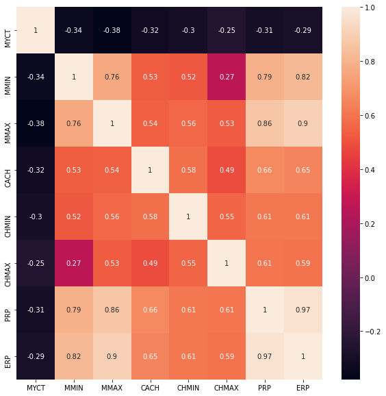

```python
plt.subplots(figsize=(10,10))
sb.heatmap(data.corr(),annot=True)
```

## Encoding the vendors

```python
enc=preprocessing.LabelEncoder()
data['Vendor']=enc.fit_transform(data['Vendor'])
data
```

|  | Vendor | MYCT | MMIN | MMAX | CACH | CHMIN | CHMAX | PRP | ERP |
| --- | --- | --- | --- | --- | --- | --- | --- | --- | --- |
| 0 | 0 | 125 | 256 | 6000 | 256 | 16 | 128 | 198 | 199 |
| 1 | 1 | 29 | 8000 | 32000 | 32 | 8 | 32 | 269 | 253 |
| 2 | 1 | 29 | 8000 | 32000 | 32 | 8 | 32 | 220 | 253 |
| 3 | 1 | 29 | 8000 | 32000 | 32 | 8 | 32 | 172 | 253 |
| 4 | 1 | 29 | 8000 | 16000 | 32 | 8 | 16 | 132 | 132 |
| ... | ... | ... | ... | ... | ... | ... | ... | ... | ... |
| 204 | 27 | 124 | 1000 | 8000 | 0 | 1 | 8 | 42 | 37 |
| 205 | 27 | 98 | 1000 | 8000 | 32 | 2 | 8 | 46 | 50 |
| 206 | 28 | 125 | 2000 | 8000 | 0 | 2 | 14 | 52 | 41 |
| 207 | 29 | 480 | 512 | 8000 | 32 | 0 | 0 | 67 | 47 |
| 208 | 29 | 480 | 1000 | 4000 | 0 | 0 | 0 | 45 | 25 |

209 rows × 9 columns

## Scaling the numerical data types

```python
minmax=preprocessing.MinMaxScaler()
data[['MYCT','MMIN','MMAX','CACH','CHMIN','CHMAX','PRP']]=minmax.fit_transform(data[['MYCT','MMIN','MMAX','CACH','CHMIN','CHMAX','PRP']])
```

```python
data
```

|  | Vendor | MYCT | MMIN | MMAX | CACH | CHMIN | CHMAX | PRP | ERP |
| --- | --- | --- | --- | --- | --- | --- | --- | --- | --- |
| 0 | 0 | 0.072825 | 0.006012 | 0.092843 | 1.000 | 0.307692 | 0.727273 | 0.167832 | 199 |
| 1 | 1 | 0.008092 | 0.248497 | 0.499499 | 0.125 | 0.153846 | 0.181818 | 0.229895 | 253 |
| 2 | 1 | 0.008092 | 0.248497 | 0.499499 | 0.125 | 0.153846 | 0.181818 | 0.187063 | 253 |
| 3 | 1 | 0.008092 | 0.248497 | 0.499499 | 0.125 | 0.153846 | 0.181818 | 0.145105 | 253 |
| 4 | 1 | 0.008092 | 0.248497 | 0.249249 | 0.125 | 0.153846 | 0.090909 | 0.110140 | 132 |
| ... | ... | ... | ... | ... | ... | ... | ... | ... | ... |
| 204 | 27 | 0.072151 | 0.029309 | 0.124124 | 0.000 | 0.019231 | 0.045455 | 0.031469 | 37 |
| 205 | 27 | 0.054619 | 0.029309 | 0.124124 | 0.125 | 0.038462 | 0.045455 | 0.034965 | 50 |
| 206 | 28 | 0.072825 | 0.060621 | 0.124124 | 0.000 | 0.038462 | 0.079545 | 0.040210 | 41 |
| 207 | 29 | 0.312205 | 0.014028 | 0.124124 | 0.125 | 0.000000 | 0.000000 | 0.053322 | 47 |
| 208 | 29 | 0.312205 | 0.029309 | 0.061562 | 0.000 | 0.000000 | 0.000000 | 0.034091 | 25 |

209 rows × 9 columns

## Splitting the training and testing data

```python
X=data[['Vendor','MYCT','MMIN','MMAX','CACH','CHMIN','CHMAX','PRP']]
y=data[['ERP']]
X_train, X_test, y_train, y_test = train_test_split(X,y, test_size=0.30, random_state=42)
```

## Forming the regression model

```python
reg=linear_model.LinearRegression()
```

```python
reg.fit(X_train,y_train)
pred=reg.predict(X_test)
print('Coefficients: ',reg.coef_)
print('Intercept: ',reg.intercept_)
```

```
Coefficients:  [[-2.01946850e-01  4.23210631e+01  2.10880411e+02  2.95030038e+02
   8.43877308e+01  5.70099370e+01  1.01564365e+01  3.09092001e+02]]
Intercept:  [-21.94711602]
```

## Evaluating the model

```python
print('Mean Absolute Error:', metrics.mean_absolute_error(y_test, pred))
print('Mean Squared Error:', metrics.mean_squared_error(y_test, pred))
print('Root Mean Squared Error:', np.sqrt(metrics.mean_squared_error(y_test, pred)))
```

```
Mean Absolute Error: 29.493058841753196
Mean Squared Error: 5370.460765296976
Root Mean Squared Error: 73.28342763065177
```

```python
print(metrics.r2_score(y_test,pred))
```

```
0.9003421925593021
```

R2 score suggests that the model is quite good.